# Reproducible Research Peer Assessment 1

## by LRG2000

```r
opts_chunk$set(echo = TRUE)
opts_chunk$set(message = FALSE)
```

First, read in the data:

```r
data <- read.csv("activity.csv", stringsAsFactors = FALSE)
```

Now we can begin to answer questions about this dataset. The data consist of the number of steps taken summed over 5-minute intervals. The first “question”“ asks for a histogram of the total number of steps taken each day, the median and mean number of steps taken each day.

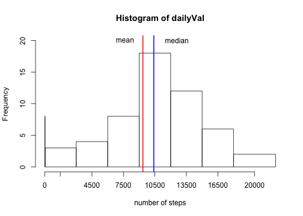

```r
s <- split(data, data$date)
dailyVal <- numeric(length(s))
for (i in 1:length(s)) {
    dailyVal[i] <- sum(s[[i]]$steps[!is.na(s[[i]]$steps)])
}
hbreaks <- c(0, 40, 3000, 6000, 9000, 12000, 15000, 18000, 22000)
plotbreaks <- c(0, 1480, 4500, 7500, 10500, 13500, 16500, 20000)
hist(dailyVal, breaks = hbreaks, freq = TRUE, xaxt = "n", xlab = "number of steps",
    ylim = c(0, 20))
axis(side = 1, at = plotbreaks, labels = as.character(plotbreaks))
abline(v = mean(dailyVal), col = "red", lwd = 2)
text(mean(dailyVal) - 1700, y = 20, labels = "mean")
abline(v = median(dailyVal), col = "blue", lwd = 2)
text(median(dailyVal) + 2200, y = 20, labels = "median")
```

We can also look at the average number of steps in each time interval. The time intervals listed below begin at the 24-hour time specified.

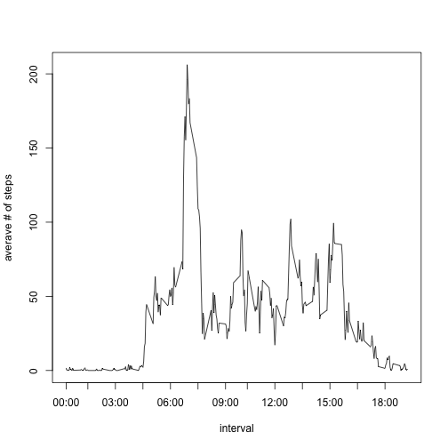

```r
interval_a <- as.character(10000 + s[[1]]$interval)
interval <- character(288)
intAve <- numeric(288)
int.df <- data.frame(s)
steps <- NULL
for (i in 1:288) {
    ## get the interval number to look like a time
    interval[i] <- paste(substr(interval_a[i], 2, 3), ":", substr(interval_a[i],
        4, 5), sep = "", collapse = "")
}
for (i in 1:61) {
    steps <- rbind(steps, s[[i]]$steps)
}
means <- colMeans(steps, na.rm = TRUE)
plot(s[[1]]$interval, means, xaxt = "n", type = "l", xlab = "interval", ylab = "averave # of steps")
axis(side = 1, labels = interval[c(1, (1 + 18 * (1:12)))], at = s[[1]]$interval[c(1,
    (1 + 22 * (1:12)))], lwd.ticks = 1)
```

```r
ind1 <- is.na(data$steps)
ind2 <- is.na(data$interval[!ind1])
nas <- sum(ind1) + sum(ind2)
```

After checking the numbers of NAs in the individual elements, we found that there are 2304 NAs in the "steps” element, and none in the other two list elements. We're going replace any NA values in an interval with the mean number of steps in that interval. Then we will calculate the total number of steps taken each day with these values.

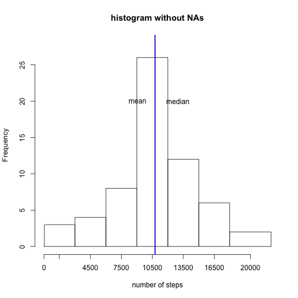

```r
nsteps <- split(data$steps, data$interval)
for (i in 1:288) {
    ind <- is.na(nsteps[[i]])
    if (sum(ind > 0)) {
        nsteps[[i]][ind] <- means[i]
    }
}
newDailyVal <- numeric(61)
for (i in 1:61) {
    s[[i]]$steps[is.na(s[[i]]$steps)] <- means[is.na(s[[i]]$steps)]
    newDailyVal[i] <- sum(s[[i]]$steps)
}

hist(newDailyVal, breaks = hbreaks, freq = TRUE, xaxt = "n", xlab = "number of steps",
    ylim = c(0, 28), main = "histogram without NAs")
axis(side = 1, at = plotbreaks, labels = as.character(plotbreaks))
abline(v = mean(newDailyVal), col = "red", lwd = 2)
text(mean(newDailyVal) - 1700, y = 20, labels = "mean")
abline(v = median(newDailyVal), col = "blue", lwd = 2)
text(median(newDailyVal) + 2200, y = 20, labels = "median")
```

We see that the mean and median are now in the same place, at 10766 . The mean before replacing NAs was 9354, while the old median was 10395.

Now we will look for differences in activity on weekends and weekdays.

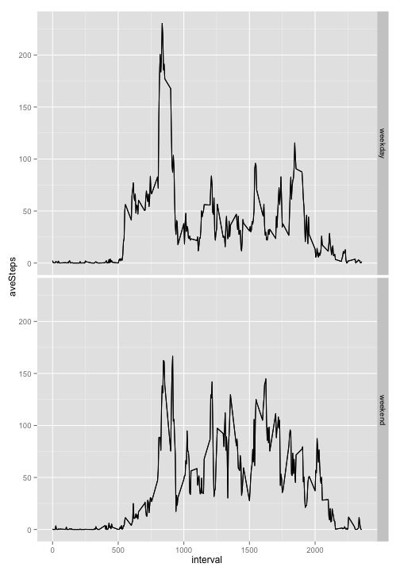

```r
us <- unsplit(s, data$date)
date <- as.Date(us$date)
days <- weekdays(date)
wkends <- grepl("Sunday", days) | grepl("Saturday", days)
dayType <- character(length(us$date))
dayType[wkends] <- "weekend"
dayType[!wkends] <- "weekday"
us <- cbind(us, dayType)
wks <- split(us, dayType)
dayInts <- split(wks[["weekday"]], wks[["weekday"]]$interval)
endInts <- split(wks[["weekend"]], wks[["weekend"]]$interval)

plotme <- data.frame(aveSteps = numeric(576), dayType = character(576), interval = rep(s[[1]]$interval,
    2), stringsAsFactors = FALSE)
for (i in 1:288) {
    plotme$aveSteps[i] <- mean(dayInts[[i]]$steps)
    plotme$aveSteps[288 + i] <- mean(endInts[[i]]$steps)
    plotme$dayType[i] <- "weekday"
    plotme$dayType[i + 288] <- "weekend"
}

library(ggplot2)
qplot(interval, aveSteps, data = plotme, geom = "line") + geom_line() + facet_grid(dayType ~
    .)
```